# The Safety Net of Safety Nets: Peer-to-Peer Mutual Aid

Author

Kim Nguyen

Published

August 2023

[interactive chart not shown]

[figure not shown]

How do the poor make ends meet? To the average person, it’s presumed assistance is sought through government social programs — if you happen to not qualify for those programs, then there are always non-profit initiatives. But what happens when the conventional avenues of giving, namely through government or philanthropic programming, are unavailable? Mutual aid, which also seeks to accomplish the goal of assistance, is seldom brought up as a viable alternative. Mutual aid is unique in its mode of operation, and despite many mutual aid networks cropping up during the height of the pandemic it has yet to reach levels required to make its practice commonplace. What makes it difficult to implement into the mainstream lies within its definition.

In the context of organizational theory, mutual aid is material redistribution operating within the system; in its simplest application, it exists as a communal transaction, where one party directly meets the needs of the other, circumventing the conditions or prerequisites set forth by liaising entities. This flexible definition gives rise to many different ways it can be structured, organized, and disseminated. Mutual aid can be completely decentralized, independently conducted, or akin to a corporation — it can operate on the larger scale, like GoFundMe’s crowdsourcing model, or as community initiatives like that of Asian Mutual Aid Group Inc., which is localized to New York City’s Chinese and Chinese-adjacent diaspora. [Research](https://hibar-research.org/the-impact-of-direct-giving/) conducted by the Foundations for Social Change in collaboration with the University of British Columbia, assessed the impact of directly giving cash payments to a sample homeless population. This direct-giving led to significant improvements in employment, housing stability, and wellbeing, indicating the effectiveness of direct- giving. Mutual aid also exists on the peer-to-peer scale and is not limited to the physical realm, as is the case of mutual aid groups found online (namely on Facebook).

True to the spirit of accessibility, many mutual aid groups allow members to ask for anything (“poor people also deserve nice things” is one group’s M.O). Requests can be both wants and needs of any amount and operate on the honor system, only requiring proof-of-purchase to validate that funds are going towards the request. Members ask for anything from diapers, utilities, gas, groceries, household items, and housing, to manicures, game add-ons, concert tickets, and vacations, though you are more likely to receive funding if you’re asking for a smaller amount of something you need.

[interactive chart not shown]

Table 1: Aggregated statistics across categories between non-zero funded and all requests.

In this analysis, data was sourced using requests posted on active mutual aid Facebook groups, with a sample size of 972 usable posts. Amounts received and being asked were extracted and analyzed from textual data, and were categorized accordingly. Overall, requests were fully or partially funded at a rate of 13.35%, meaning over 86% of requests were left unmet. There is also the pattern of how funding is distributed: funding also varied across categories and the vast majority of received funds were under 50 dollars, indicating that donors generally gave in smaller amounts compared to what requesters were asking.

These disparities can be explained by human psychology. As a funder, it makes sense to want to directly give towards requests that have the most impact (fully funding smaller requests vs contributing a fraction towards a larger one); conversely, if one was desperate, there is more upside to posting a request no matter the amount being asked, resulting in outliers and subsequently a larger deviation.

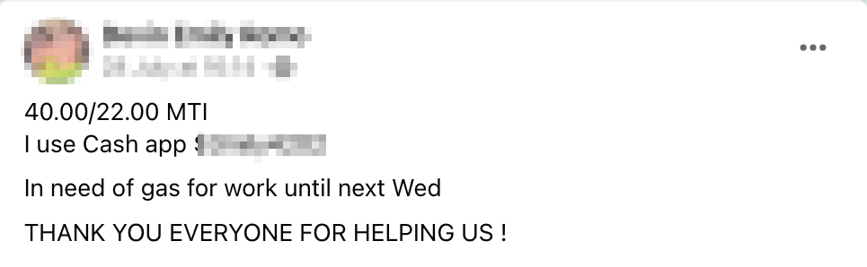

A sample post; 40 dollars was put towards the 22 dollar request, making it fully funded.

For the members asking for necessities, a quick browse paints a clear picture of what getting-by looks like on a day-to-day basis. Though “baiting” is against the rules of the group, members often share the earnest motivations behind their request — that they’re currently in the process of homelessness and need shelter for a night, or are between jobs and need a little help with expenses until they get paid.

Posts also often disclose whether they are receiving social assistance of some form, namely SNAP or housing benefits. But support from these programs is often cut-back from slight improvements in circumstances, and as one member aptly put it: it’s never enough.

[interactive chart not shown]

Figure 1: A box-plot outlining range of requests by category.

How did we get here? “Our society has become very siloed relative to how communities functioned 100 years ago,” said Laurie Styron, the CEO and Executive Director of the nonprofit watchdog, [CharityWatch](https://www.charitywatch.org/). “Many of our social interactions occur among strangers online rather than among neighbors, schoolmates, or via a religious affiliation like church or temple.”

There is also the issue of red-tape. In order to qualify for food, unemployment, housing benefits, applicants need to meet certain income or demographic requirements. They are also left with the burden of proving they need support, with applications requiring time-sensitive submissions of personal tax returns, financial statements, or social security info. Because recipients need to fall within an income bracket, there is also incentive to make less than the cut-off points in order to maintain eligibility for these programs, further perpetuating a cycle of poverty.

A report published by Indiana University’s school of philanthropy assessed that while 80% of Americans view charitable-giving as valuable, there has been an increasing trend of megagifts as inversely proportional to falling individual donor rates. This trend is also observed in a [summary](https://www.philanthropy.com/article/giving-was-up-but-the-number-of-donors-was-down-the-first-three-quarters-of-2022) from the Chronicle of Philanthropy, and measured charitable giving increasing by 4.7% in the first three quarters of 2022 with individual donors decreasing 7.1% within the same timeframe.

[interactive chart not shown]

Figure 2: A histogram with the distribution of funding across amounts and categories.

The nature of how charities get funded is a reflection of the shifting socioeconomic strata, explained Laurie. “In the past a large volume of individuals donated small amounts of money to many different charities and causes,” she said. “These days, a small handful of extremely wealthy people are picking their pet causes and charities and directing large donations to a relatively small pool of organizations.”

The end result, Laurie noted, “is that any charity not in that pool is going to struggle for funding as the pool of individual donors continues to shrink. A lot of important work isn’t going to get done just because it doesn’t happen to be the pet cause of a very wealthy donor or foundation. And the end result is that a lot of people who need help are going to slip through the cracks”

##### Methodology

Data was scraped from active mutual aid groups on Facebook, and underwent cleaning and refinement — the analysis employed linked tidy datasets, sliced and derived from a primary working dataset. Amounts were extracted and converted to floats and requests were categorized, both from raw textual post data. Analysis was made possible using an iterative approach, combining regex, NLP, and GPT.

This article was rendered using Quarto, with charts made in Observable JS. Revised analysis and cleaned results can be found in the project’s [repository](https://github.com/sherbert-lemon/mutual-aid).